# STAT 201 Week 2: Effect of Sample Size

## Orientation

Last week: sampling distributions to get a sense of the uncertainty in a point estimate.

This week: effect of sample size on sampling distribution.

Remember, our real-world task is to learn something about the population. Either:

- The full population distribution, or
- A population parameter.

Problem: both of these things are unknown. Most of the time, we only have a sample.

## Example

You’re a manager for Translink’s 4338 buses in Vancouver, who wants to know the mileage on the buses so that you can decide things like whether you’ll need new buses soon (and how many). (Numbers are fictional!)

It would be nice to know the population:

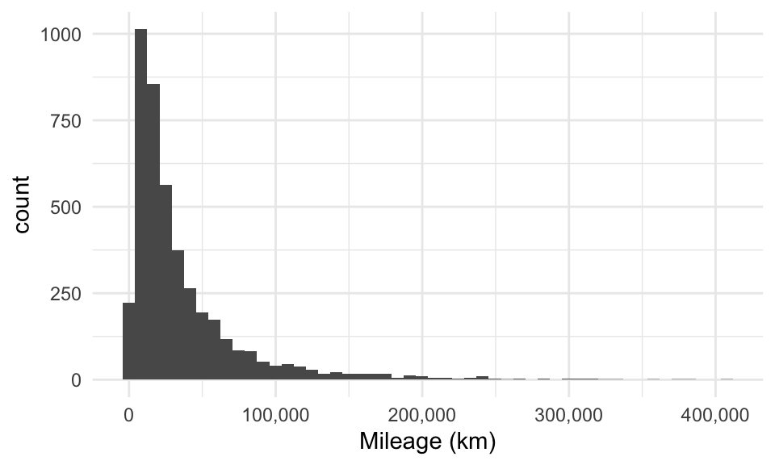

## Example

With the population, you can calculate insightful population parameters like these:

- Percent of buses above 200,000km: 0.013.
  - That’s 56 buses.
- Median: 21640km.
  - That means half the buses have more (and less) mileage than this.

Pretty good story! Most of the buses are still low. That’s valuable information!

## Reality

Problem: you don’t know the mileage on each of them, and can’t get that information.

What’s better?

1. Since you can’t get that info, don’t bother trying. Continue making decisions using information you’re certain about.
2. Ask some bus drivers to report bus mileage, and use those numbers to make decisions – despite possible inaccuracies.

## Representative Sampling

Which scenario is better? Why?

1. Visiting the bus loop at UBC, and asking bus drivers their bus’s mileage as they arrive.
2. Ask every Vancouver bus driver that’s working tomorrow to record the mileage of their bus at noon.

## Our Sample Distribution

We managed to get 200 buses that are representative of the population! Here’s their distribution (called a **sample distribution** – not to be confused with a sampl*ing* distribution!)

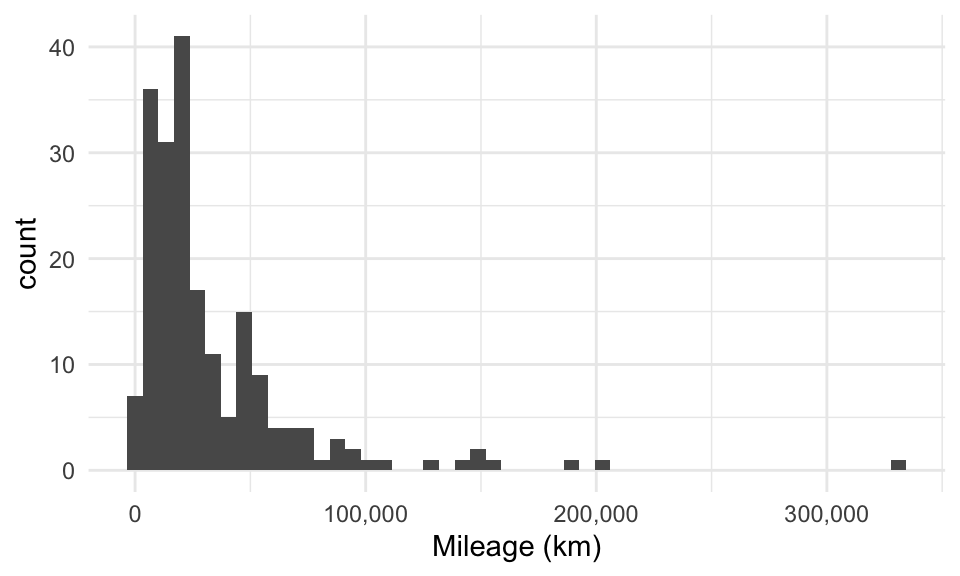

## Our Point Estimates

When calculating population parameters using a sample, the resulting numbers are called **point estimates**:

- Percent of buses above 200,000km: 0.01.
  - That’s 43 buses.
- Median: 20854km.
  - That means half the buses have more (and less) mileage than this.

Similar picture is painted as before. Most of the buses are still low.

How might this picture be different if our sample was not representative?

## Uncertainty in our Point Estimate

Let’s estimate the number of buses above 200,000km by drawing a sample of size 200, 1000 times:

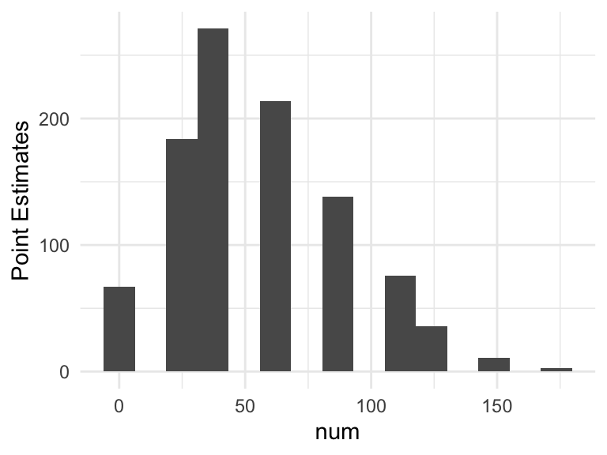

Standard deviation of the sampling distribution = *standard error* = 34.1766804.

## Different Sample Size

What if we ended up taking samples of size 1000 instead of 200? Here’s the sampling distribution under that scenario:

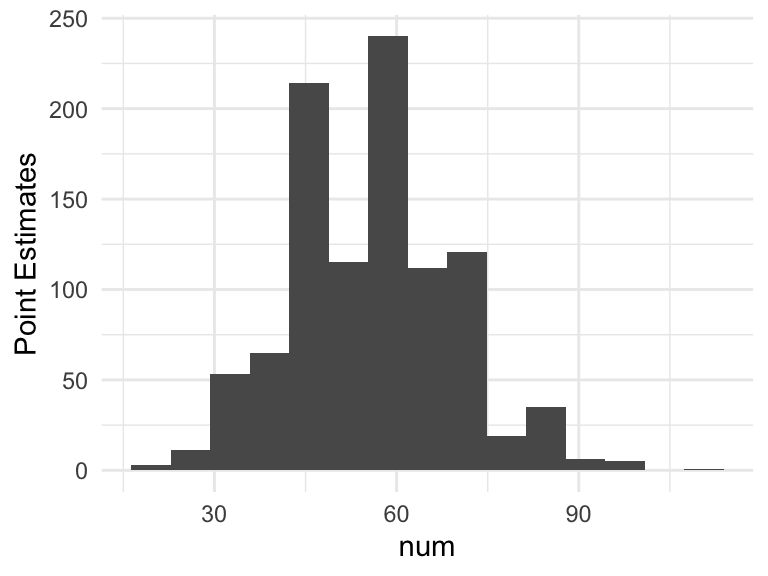

Standard deviation of the sampling distribution = *standard error* = 13.423209.

What do you notice?